# You Try Answers: Simple Linear Regression

POSC 8410

Author

Will Horne

Published

November 10, 2026

```r
library(tidyverse)
library(gapminder)   # install.packages("gapminder") if you do not have it

# Same data as the slides: countries in 2007, with log GDP per capita
g07 <- gapminder |> filter(year == 2007) |> mutate(lgdp = log(gdpPercap))
m1  <- lm(lifeExp ~ lgdp, data = g07)
```

## You Try

**1. Regress `lifeExp` on unlogged `gdpPercap`. Compare** $R^2$ to the logged version. Which fits better, and why?

```r
m0 <- lm(lifeExp ~ gdpPercap, data = g07)

c(unlogged = summary(m0)$r.squared,
  logged   = summary(m1)$r.squared)
```

```
 unlogged    logged
0.4605827 0.6544490
```

**The logged model fits better.** Log GDP accounts for 65% of the variation in life expectancy; GDP in dollars accounts for 46%.

The reason is the shape of the relationship. Plot both versions:

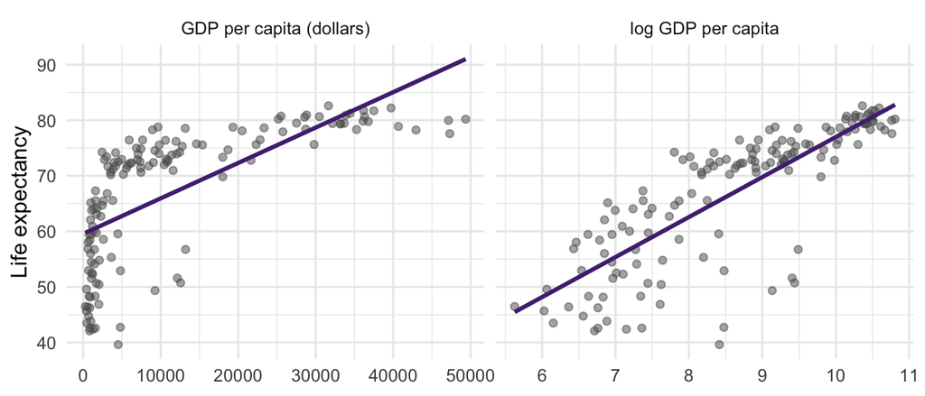

```r
g07 |>
  pivot_longer(c(gdpPercap, lgdp), names_to = "scale", values_to = "x") |>
  mutate(scale = if_else(scale == "gdpPercap",
                         "GDP per capita (dollars)", "log GDP per capita")) |>
  ggplot(aes(x, lifeExp)) +
  geom_point(alpha = .5, color = "grey35") +
  geom_smooth(method = "lm", se = FALSE, color = "#522D80") +
  facet_wrap(~ scale, scales = "free_x") +
  labs(x = NULL, y = "Life expectancy") +
  theme_minimal(base_size = 12)
```

In dollars, life expectancy rises steeply among poor countries and then levels off. An extra $1,000 matters enormously in a country with $1,500 per person and barely at all in one with $40,000. A straight line cannot capture those dynamics, so it misses badly in both regions. Taking logs stretches out the poor countries and compresses the rich ones, which turns “each extra dollar matters less” into “each *doubling* matters the same,” which is closer to a straight line.

The residual standard error tells the same story: a typical miss of 8.9 years unlogged against 7.1 years logged.

This comparison of $R^2$ is fair because both models predict the same outcome, `lifeExp`. You could **not** compare $R^2$ between a model for `lifeExp` and one for `log(lifeExp)`, because they would be explaining variation in different quantities.

**2. Compute the slope by hand with `cov` and `var`. Does it match `lm`?**

```r
with(g07, cov(lgdp, lifeExp) / var(lgdp))   # by hand
```

```
[1] 7.202802
```

```r
coef(m1)["lgdp"]                            # from lm
```

```
    lgdp
7.202802
```

**Yes, they match exactly.** This is the formula from the slides, $\hat{\beta}_1 = \widehat{\text{Cov}}(X, Y) / \widehat{\text{Var}}(X)$.

**3. Verify the fitted line passes through** $(\bar{x}, \bar{y})$.

Ask the model for its prediction at the mean of $X$, and compare that with the mean of $Y$:

```r
predict(m1, newdata = tibble(lgdp = mean(g07$lgdp)))   # fitted value at x-bar
```

```
       1
67.00742
```

```r
mean(g07$lifeExp)                                      # y-bar
```

```
[1] 67.00742
```

**They are identical.** This follows from the first least squares condition. Setting the derivative with respect to $\beta_0$ to zero gave $\bar{y} = \hat{\beta}_0 + \hat{\beta}_1 \bar{x}$, which says precisely that the point $(\bar{x}, \bar{y})$ lies on the line.

You can also check it with the coefficients directly:

```r
coef(m1)[1] + coef(m1)[2] * mean(g07$lgdp) - mean(g07$lifeExp)  # ~zero
```

```
  (Intercept)
-1.421085e-14
```

**4. Center `lgdp` by subtracting its mean and refit. Which coefficient changed, and which did not?**

```r
g07 <- g07 |> mutate(lgdp_c = lgdp - mean(lgdp))
m1c <- lm(lifeExp ~ lgdp_c, data = g07)

rbind(original = coef(m1),
      centered = coef(m1c))
```

```
         (Intercept)     lgdp
original    4.949612 7.202802
centered   67.007423 7.202802
```

**The intercept changed; the slope stayed the same.**

- **The slope stays at 7.20.** Subtracting a constant from $X$ slides every point left by the same amount.
- **The intercept becomes** $\bar{y}$ = 67.01. After centering, $X = 0$ means “a country at the mean of log GDP.”